# Data Challenge

Chaitra Rao

#### Load libraries

```r
library(dplyr)
library(tidyverse)
library(mlr)
library(gridExtra)
library(ggfortify)
library(edgeR)
library(org.Hs.eg.db)
library(RColorBrewer)
library(gplots)
library(tidyr)
library(pheatmap)
library(reshape2)
library(survminer)
library(rms)
library(pheatmap)
library(ggplot2)

my_theme <- function(base_size =9, base_family = "sans"){
  theme_minimal(base_size = base_size, base_family = base_family) +
    theme(
      axis.text = element_text(size=8),
      axis.text.x = element_text(angle = 0, vjust = 0.5, hjust = 0.5),
      axis.title = element_text(size =8),
      panel.grid.major = element_line(color = "gray"),
      panel.grid.minor = element_blank(),
      panel.background = element_rect(fill = "#ffffff"),
      strip.background = element_rect(fill = "black", color = "black", size =0.5),
      strip.text = element_text(face = "bold", size = 8, color = "white"),
      legend.position = "bottom",
      legend.justification = "center",
      legend.background = element_blank(),
      panel.border = element_rect(color = "grey5", fill = NA, size = 0.5)
    )
}

theme_set(my_theme())

mycolors=c("darkred","black","#004431","#000c44","#2d1600","purple","#202302")
myfillcolors=c("#d10c0c","grey10","#1e6651","#213989","#5b431a","purple","#393f03")
```

### Clinical data exploration

#### 1. Prepare data and explore basic demographics

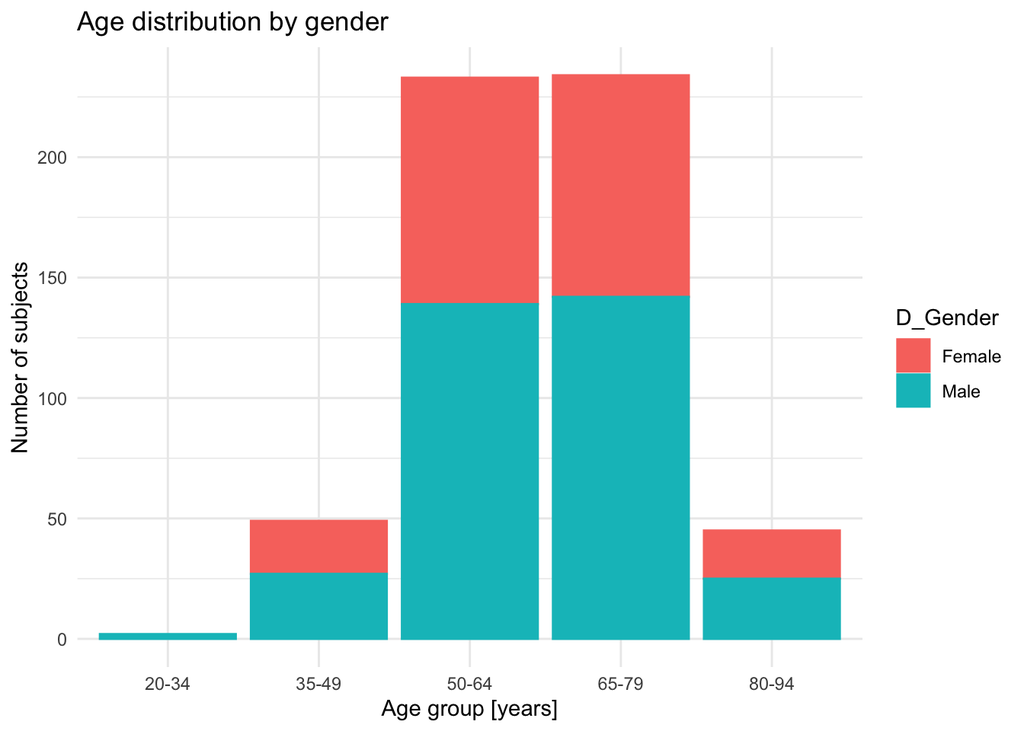

```r
clin_data <- read.csv("sc3_Training_ClinAnnotations.csv")

## group age into bins for visualization purposes
labs <- c(paste(seq(20, 80, by=15), seq(20+15-1, 95-1, by=15), sep="-"))
clin_data$agegrp <- cut(clin_data$D_Age, breaks=c(seq(20,80, by=15), Inf), labels=labs, right=F)

## assumption: events where it is not TRUE (event did not occur) are assumed to be censored
## 131 out of 583 events occured and rest are censored
clin_data$HR_FLAG <- clin_data$HR_FLAG==TRUE

## explore how many events occurred and how many censored

## check % of NAs present in each column of the dataset
nacount <- apply(clin_data, 2, function(x){
  sum(is.na(x))
})
nacount <- as.data.frame(nacount, row.names=names(clin_data))
nacount <- add_rownames(nacount) %>% dplyr::mutate(percentNA=round(nacount/583*100,2))%>%
  dplyr::filter(percentNA>=0.00)

## remove columns where NAs >50%
cols_to_remove <- nacount[nacount$percentNA>50,]$rowname
clin_data <- clin_data[, !(names(clin_data) %in% cols_to_remove)]

## remove unnecessary columns -> keep only D_PFS as time column,  remove file info columns,
## study and patient status columns also removed (all same)
clin_data <- clin_data[, -c(1, 5:6, 8, 10:11,13:17)]

## remove NAs (only 20 in D_ISS column)
clin_data <- clin_data[complete.cases(clin_data),]

## age by gender distribution plot
clin_data %>% ggplot(aes(x=agegrp, color=D_Gender, fill=D_Gender))+geom_bar()+
  ggtitle("Age distribution by gender")+xlab("Age group [years]")+ylab("Number of subjects")+theme_minimal()
```

#### 2. Explore effect of factors like age and ISS on survival

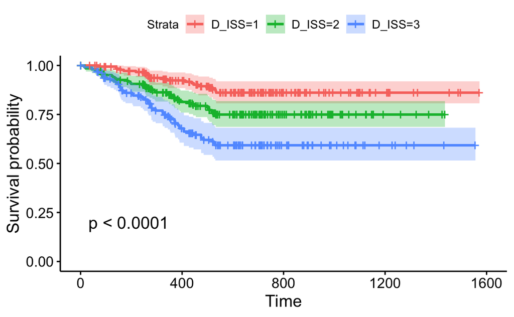

```r
par(mfrow=c(1,2))

## Kaplan-Meier curve for Death events in patients stratified by age and ISS
surv_plots <- list()
fit_iss=survival::survfit(survival::Surv(D_PFS,HR_FLAG)~D_ISS,data=clin_data)
ggsurvplot(fit_iss, pval = TRUE, conf.int = TRUE)
```

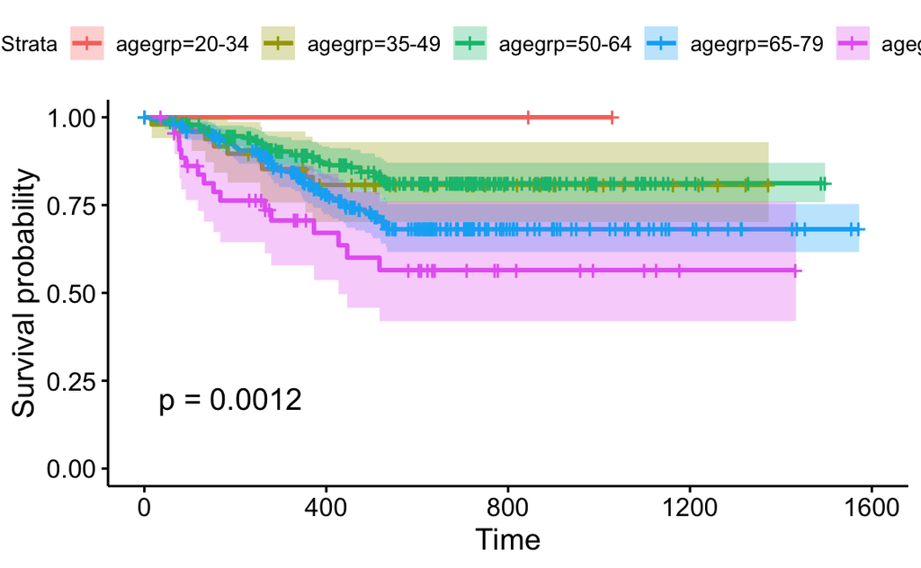

```r
#autoplot(fit_iss)+scale_color_manual(values=mycolors)+scale_fill_manual(values=myfillcolors)

fit_age = survival::survfit(survival::Surv(D_PFS,HR_FLAG)~agegrp,data=clin_data)
ggsurvplot(fit_age, pval = TRUE, conf.int = TRUE)
```

```r
#autoplot(fit_age)+scale_color_manual(values=mycolors)+scale_fill_manual(values=myfillcolors)
```

These figures indicate that the patients who were in their third stage and belonged to an older have higher aurvival risk. Now, that it’s established that both age and ISS can be important predictors of MM death or relapse, a small 2-predictor model was built to apply a Cox regression model and predict the survival time using the main effects of the two predictors - age and ISS.

```r
## simple 2-predictor model with coxph using only age and ISS
age_iss_model <- survival::coxph(survival::Surv(D_PFS,HR_FLAG) ~
                          D_Age + D_ISS , data=clin_data)


summary(age_iss_model)
```

```
## Call:
## survival::coxph(formula = survival::Surv(D_PFS, HR_FLAG) ~ D_Age +
##     D_ISS, data = clin_data)
##
##   n= 563, number of events= 122
##
##           coef exp(coef) se(coef)     z Pr(>|z|)
## D_Age 0.026554  1.026909 0.008763 3.030  0.00244 **
## D_ISS 0.581850  1.789346 0.122814 4.738 2.16e-06 ***
## ---
## Signif. codes:  0 '***' 0.001 '**' 0.01 '*' 0.05 '.' 0.1 ' ' 1
##
##       exp(coef) exp(-coef) lower .95 upper .95
## D_Age     1.027     0.9738     1.009     1.045
## D_ISS     1.789     0.5589     1.407     2.276
##
## Concordance= 0.662  (se = 0.025 )
## Likelihood ratio test= 39.91  on 2 df,   p=2e-09
## Wald test            = 38.42  on 2 df,   p=5e-09
## Score (logrank) test = 40.15  on 2 df,   p=2e-09
```

Again, it appears that both age and ISS have a statistically significant effect, as predictors in the model.

#### 3. Explore effects of cytogenetic features on survival

```r
## simple 13-predictor model using only cyto features with coxph - to detect which cyto features could be relevant as significant predictors
cyto_feat_model <- survival::coxph(survival::Surv(D_PFS,HR_FLAG) ~
                                     CYTO_predicted_feature_01+CYTO_predicted_feature_02+CYTO_predicted_feature_03+
                                     CYTO_predicted_feature_05+CYTO_predicted_feature_06+CYTO_predicted_feature_08+
                                     CYTO_predicted_feature_12+CYTO_predicted_feature_13+CYTO_predicted_feature_14+
                                     CYTO_predicted_feature_15+CYTO_predicted_feature_16+CYTO_predicted_feature_17+
                                     CYTO_predicted_feature_18, data=clin_data)
summary(cyto_feat_model)
```

```
## Call:
## survival::coxph(formula = survival::Surv(D_PFS, HR_FLAG) ~ CYTO_predicted_feature_01 +
##     CYTO_predicted_feature_02 + CYTO_predicted_feature_03 + CYTO_predicted_feature_05 +
##     CYTO_predicted_feature_06 + CYTO_predicted_feature_08 + CYTO_predicted_feature_12 +
##     CYTO_predicted_feature_13 + CYTO_predicted_feature_14 + CYTO_predicted_feature_15 +
##     CYTO_predicted_feature_16 + CYTO_predicted_feature_17 + CYTO_predicted_feature_18,
##     data = clin_data)
##
##   n= 563, number of events= 122
##
##                               coef exp(coef) se(coef)      z Pr(>|z|)
## CYTO_predicted_feature_01  0.41477   1.51402  0.20968  1.978  0.04791 *
## CYTO_predicted_feature_02  0.74766   2.11204  0.73900  1.012  0.31168
## CYTO_predicted_feature_03 -1.01689   0.36172  0.33074 -3.075  0.00211 **
## CYTO_predicted_feature_05  0.18337   1.20126  0.21800  0.841  0.40024
## CYTO_predicted_feature_06  0.24968   1.28362  0.26331  0.948  0.34301
## CYTO_predicted_feature_08  0.27432   1.31563  0.29038  0.945  0.34481
## CYTO_predicted_feature_12  0.58770   1.79985  1.64586  0.357  0.72103
## CYTO_predicted_feature_13 -0.14107   0.86843  0.38509 -0.366  0.71413
## CYTO_predicted_feature_14  1.04206   2.83506  0.48209  2.162  0.03065 *
## CYTO_predicted_feature_15  0.02776   1.02815  0.27154  0.102  0.91856
## CYTO_predicted_feature_16 -0.51062   0.60012  1.01129 -0.505  0.61361
## CYTO_predicted_feature_17       NA        NA  0.00000     NA       NA
## CYTO_predicted_feature_18 -0.04945   0.95175  0.34209 -0.145  0.88506
## ---
## Signif. codes:  0 '***' 0.001 '**' 0.01 '*' 0.05 '.' 0.1 ' ' 1
##
##                           exp(coef) exp(-coef) lower .95 upper .95
## CYTO_predicted_feature_01    1.5140     0.6605   1.00382    2.2835
## CYTO_predicted_feature_02    2.1120     0.4735   0.49621    8.9896
## CYTO_predicted_feature_03    0.3617     2.7646   0.18917    0.6917
## CYTO_predicted_feature_05    1.2013     0.8325   0.78357    1.8416
## CYTO_predicted_feature_06    1.2836     0.7790   0.76613    2.1506
## CYTO_predicted_feature_08    1.3156     0.7601   0.74467    2.3244
## CYTO_predicted_feature_12    1.7998     0.5556   0.07150   45.3101
## CYTO_predicted_feature_13    0.8684     1.1515   0.40827    1.8473
## CYTO_predicted_feature_14    2.8351     0.3527   1.10205    7.2933
## CYTO_predicted_feature_15    1.0282     0.9726   0.60384    1.7506
## CYTO_predicted_feature_16    0.6001     1.6663   0.08269    4.3556
## CYTO_predicted_feature_17        NA         NA        NA        NA
## CYTO_predicted_feature_18    0.9518     1.0507   0.48678    1.8608
##
## Concordance= 0.61  (se = 0.026 )
## Likelihood ratio test= 20.78  on 12 df,   p=0.05
## Wald test            = 20.07  on 12 df,   p=0.07
## Score (logrank) test = 21.3  on 12 df,   p=0.05
```

Cox regression model built using only the 13 cytogenetic features suggests that only 3 out of 13 features have statistically significant effect on survival. Therefore, we select these 3 features for our further analysis. Next, we look at the Kaplan-meier curves for these 3 features.

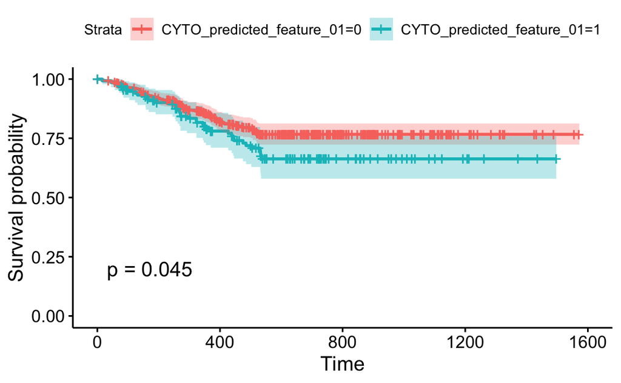

```r
par(mfrow=c(1,3))
fit_cyto1 = survival::survfit(survival::Surv(D_PFS,HR_FLAG)~CYTO_predicted_feature_01,data=clin_data)
fit_cyto3 = survival::survfit(survival::Surv(D_PFS,HR_FLAG)~CYTO_predicted_feature_03,data=clin_data)
fit_cyto14 = survival::survfit(survival::Surv(D_PFS,HR_FLAG)~CYTO_predicted_feature_14,data=clin_data)
ggsurvplot(fit_cyto1,
           pval = TRUE, conf.int = TRUE)
```

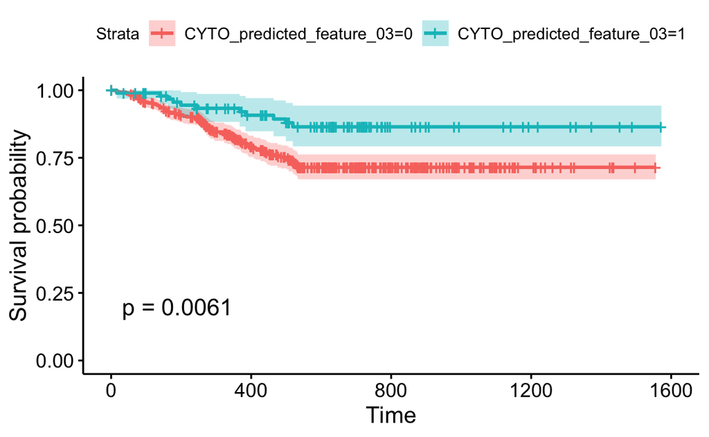

```r
ggsurvplot(fit_cyto3,
           pval = TRUE, conf.int = TRUE)
```

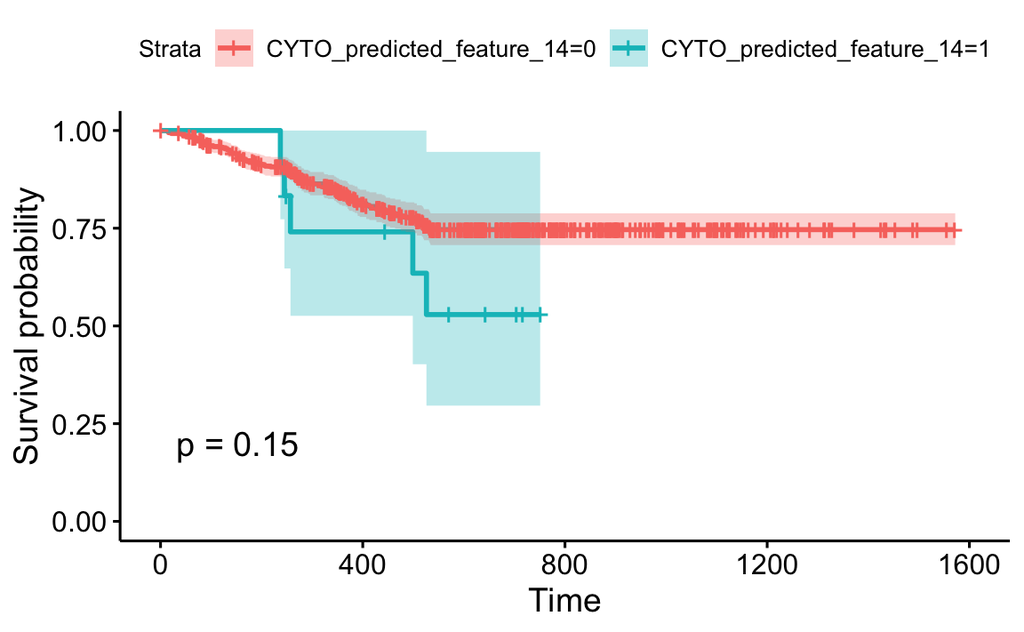

```r
ggsurvplot(fit_cyto14,
           pval = TRUE, conf.int = TRUE)
```

```r
## include only these 3 cyto features as they seem to have significant effect on survival
clin_data <- clin_data %>% dplyr::select(-c("CYTO_predicted_feature_02",
                                            "CYTO_predicted_feature_05", "CYTO_predicted_feature_06", "CYTO_predicted_feature_08",
                                            "CYTO_predicted_feature_12", "CYTO_predicted_feature_13",
                                            "CYTO_predicted_feature_15", "CYTO_predicted_feature_16", "CYTO_predicted_feature_17",
                                            "CYTO_predicted_feature_18"))
```

#### 4. Descriptive statistics

```r
## Descriptive statistics

psych::describeBy(clin_data$D_PFS,group=clin_data$CYTO_predicted_feature_01)
```

```
##
##  Descriptive statistics by group
## group: 0
##    vars   n   mean    sd median trimmed    mad min  max range skew kurtosis    se
## X1    1 425 547.42 320.8    521  527.44 326.17   1 1572  1571 0.56     0.01 15.56
## ---------------------------------------------------------------------------------
## group: 1
##    vars   n  mean     sd median trimmed    mad min  max range skew kurtosis    se
## X1    1 138 518.5 332.02    480  492.79 335.07   1 1497  1496 0.65    -0.06 28.26
```

```r
psych::describeBy(clin_data$D_PFS,group=clin_data$CYTO_predicted_feature_03)
```

```
##
##  Descriptive statistics by group
## group: 0
##    vars   n   mean     sd median trimmed    mad min  max range skew kurtosis    se
## X1    1 464 528.08 315.45    490   507.6 329.14   1 1556  1555 0.57    -0.12 14.64
## ---------------------------------------------------------------------------------
## group: 1
##    vars  n   mean     sd median trimmed    mad min  max range skew kurtosis    se
## X1    1 99 597.74 355.08    623  575.86 281.69   1 1572  1571 0.51     0.08 35.69
```

```r
psych::describeBy(clin_data$D_PFS,group=clin_data$CYTO_predicted_feature_14)
```

```
##
##  Descriptive statistics by group
## group: 0
##    vars   n   mean     sd median trimmed    mad min  max range skew kurtosis    se
## X1    1 551 541.49 325.73    517  520.02 327.65   1 1572  1571 0.57    -0.04 13.88
## ---------------------------------------------------------------------------------
## group: 1
##    vars  n mean     sd median trimmed   mad min max range  skew kurtosis    se
## X1    1 12  487 198.91  512.5   485.6 294.3 237 751   514 -0.11    -1.73 57.42
```

```r
psych::describeBy(clin_data$D_PFS,group=clin_data$agegrp)
```

```
##
##  Descriptive statistics by group
## group: 20-34
##    vars n  mean     sd median trimmed    mad min  max range skew kurtosis   se
## X1    1 2 937.5 130.81  937.5   937.5 137.14 845 1030   185    0    -2.75 92.5
## ---------------------------------------------------------------------------------
## group: 35-49
##    vars  n   mean     sd median trimmed    mad min  max range skew kurtosis    se
## X1    1 49 649.43 345.94    710  641.73 330.62  16 1373  1357 0.09    -0.79 49.42
## ---------------------------------------------------------------------------------
## group: 50-64
##    vars   n   mean    sd median trimmed    mad min  max range skew kurtosis    se
## X1    1 233 552.45 304.7    541  539.07 299.49   1 1497  1496 0.38     -0.2 19.96
## ---------------------------------------------------------------------------------
## group: 65-79
##    vars   n  mean     sd median trimmed    mad min  max range skew kurtosis    se
## X1    1 234 521.2 324.03  456.5  492.15 280.21   1 1572  1571 0.85     0.62 21.18
## ---------------------------------------------------------------------------------
## group: 80-94
##    vars  n   mean     sd median trimmed    mad min  max range skew kurtosis    se
## X1    1 45 440.64 356.54    331  398.95 370.65  36 1433  1397  0.9     -0.1 53.15
```

```r
psych::describeBy(clin_data$D_PFS,group=clin_data$D_ISS)
```

```
##
##  Descriptive statistics by group
## group: 1
##    vars   n   mean     sd median trimmed    mad min  max range skew kurtosis    se
## X1    1 189 593.67 323.77    595  574.72 309.86   1 1572  1571 0.55     0.09 23.55
## ---------------------------------------------------------------------------------
## group: 2
##    vars   n   mean     sd median trimmed    mad min  max range skew kurtosis    se
## X1    1 209 534.31 311.37    510  518.53 318.76   1 1436  1435 0.48    -0.14 21.54
## ---------------------------------------------------------------------------------
## group: 3
##    vars   n   mean     sd median trimmed    mad min  max range skew kurtosis    se
## X1    1 165 486.87 330.68    427  456.62 363.24   1 1556  1555 0.76     0.08 25.74
```

The descriptive analysis of the relevant factors from the clinical data show that median survival time is different across the different groups of features. It will be interesting to see how these features combined with expression data perform in the predictive analyis and contribute to the prediction of death or relapse risk in newly diagnosed MM patients.

### Expression data exploration

Next, we will start to look into the expression dataset and later integrate it with the clinical data to train a predictive model. We filter the expression dataset for only those genes which are known to be of high risk for death and relapse in MM patients. A thorough literature research was done for this. Furthermore, only those samples for which we also have clinical data available will be used for the further analysis. This way it becomes to easier to integrate the two datasets to build a predictive model.

#### 1. Prepare data

```r
exp_data <- read.csv("MMRF_CoMMpass_IA9_E74GTF_Salmon_entrezID_TPM_hg19.csv")

## list the risk genes - based on literature research

riskgenes <- c("KRAS", "NRAS", "DIS3", "TENT5C",
               "BRAF","HUWE1", "TP53", "TRAF3",
               "EGR1", "ATM", "H1-4", "FGFR3", "UBR5", "PRKD2", "CYLD", "ACTG1",
               "IRF4", "MAX", "KMT2C", "CREBBP", "CCND1", "ARID1A", "EPAS1",
               "ERC2", "PRC1", "CSGALNACT1", "PHF19", "NSD2")

# Remove first column from expdata - countdata, contains only the counts for all samples.
countdata_initial <- exp_data[,-1]

# Store EntrezGeneID as rownames
rownames(countdata_initial) <- exp_data[,1]

# make dgelist object
dge_initial <- DGEList(countdata_initial)

## get annotations for entrez ids
ann <- select(org.Hs.eg.db,keys=rownames(dge_initial$counts),columns=c("ENTREZID","SYMBOL","GENENAME"))

##double check that the ENTREZID column matches exactly to our rownames in our count data.
table(ann$ENTREZID==rownames(dge_initial$counts))
```

```
##
##  TRUE
## 24128
```

```r
## add this information to expression dataset
exp_data$genes <- ann$SYMBOL

## filter expression dataset for risk genes
mm_risk <- exp_data %>% dplyr::filter(genes %in% riskgenes)

## filter for samples where clinical info also available
mm_risk_expdata <- mm_risk[, colnames(mm_risk) %in% clin_data$RNASeq_transLevelExpFileSamplId]

## bring columns in expression data in the correct order as in the clinical dataset
mm_risk_expdata <- mm_risk_expdata[clin_data$RNASeq_transLevelExpFileSamplId]

##rename entrez id and gene columns
mm_risk_expdata$Entrez_Id <- mm_risk$X
mm_risk_expdata$Gene <- mm_risk$genes

## make new countdata using the filtered dataset
countdata <- mm_risk_expdata[,-(564:565)]
# Store EntrezGeneID as rownames
rownames(countdata) <- mm_risk_expdata[,564]

##Make sure that the column names are now the same as sample name in the clinical data file. This is good because it means our sample information in clinical data is in the same order as the columns in countdata
table(colnames(countdata)==clin_data$RNASeq_transLevelExpFileSamplId)
```

```
##
## TRUE
##  563
```

```r
## make a dgelist object for visualizations, qc checks
dge <- DGEList(countdata)
```

#### 2. Quality control

Here, as I have subsetted the expression dataset for genes relevant for multiply myeloma mortality and relapse. Therefore, the filtering of lowly expressed genes (which is an important step in a standard RNASeq analysis pipeline), will be skipped and no differential analysis will be perfofmed here, as all the samples belong to the same group (newly diagnosed MM) and I want to include all these genes later in the prediction model. So, as next step, quality control on all the samples in the dataset will be performed to check that the data is of good quality, and that the samples are as we would expect.

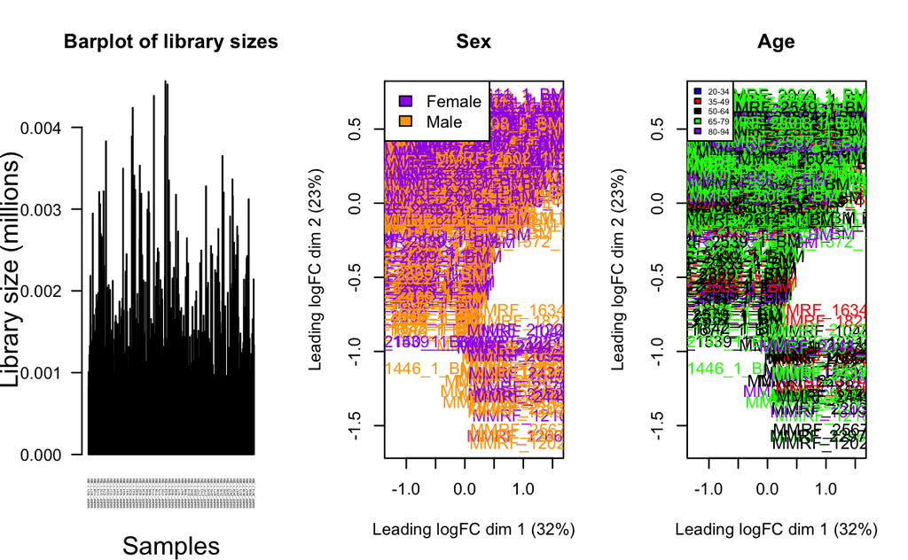

```r
par(mfrow=c(1,3))

## add clinical covariates (age+sex) to DGEList object
group_age <- factor(clin_data$agegrp)
group_sex <- factor(clin_data$D_Gender)

# Add the group information into the DGEList
dge$samples$age <- group_age
dge$samples$gender <- group_sex

## qc checks
## library size and distribution
barplot(dge$samples$lib.size/1e06, names=colnames(dge), las=2, ann=FALSE, cex.names=0.2)
mtext(side = 1, text = "Samples", line = 4)
mtext(side = 2, text = "Library size (millions)", line = 3)
title("Barplot of library sizes")

## multi-dimensional scaling plots

# set up colour schemes for age and gender

col.sex <- c("purple","orange")[as.factor(clin_data$D_Gender)]
col.age <- c("blue","red","black","green", "purple", "orange")[clin_data$agegrp]

#MDS with disease stage colouring
plotMDS(dge,col=col.sex)
# Let's add a legend to the plot so we know which colours correspond to which stage
legend("topleft",fill=c("purple","orange"),legend=levels(as.factor(clin_data$D_Gender)))
# Add a title
title("Sex")

# Similarly for age

plotMDS(dge,col=col.age)
legend("topleft",fill=c("blue","red","black","green", "purple", "orange"),legend=levels(clin_data$agegrp),cex=0.5)
title("Age")
```

We do not observe any abnormalities across the samples, as we observe that there are no clear outliers in the MDS plots. However, one would expect to observe a clear clustering of similar age groups or samples belonging to the same age or sex group cluster together and this is something we do not observe in these plots. We still decide to keep all the samples in the dataset and proceed to build a predictive model using them.

Next, we merge the two datasets.

```r
## reshape the expression dataset so that genes become column names
final_exp_data <- mm_risk_expdata[,-564] %>%
  gather(key = key, value = value, 1:563) %>%
  spread(key = names(mm_risk_expdata)[565], value = "value")

## rename the sample id column to merge with clinical data in the next step
final_exp_data <- final_exp_data %>% dplyr::rename(RNASeq_transLevelExpFileSamplId=key)

## merge clinical and expression data
clin_exp_merge <- merge(x=clin_data, y=final_exp_data, by="RNASeq_transLevelExpFileSamplId", all.x=T)

## change column names not suitable for R
clin_exp_merge <- clin_exp_merge %>% dplyr::rename(H1_4 = "H1-4")
```

#### 1. Correlation of MM relevant genes with PFS

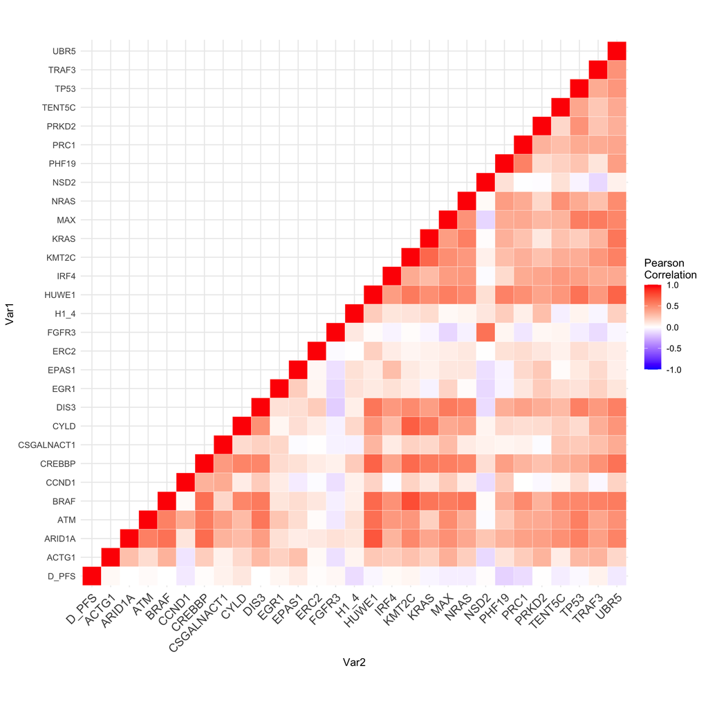

```r
## correlation of genes with event time
corres_genes <- cor(clin_exp_merge[,c(5, 12:39)], method="pearson", use="pairwise.complete.obs")

# Get lower triangle of the correlation matrix
get_lower_tri<-function(cormat){
  cormat[upper.tri(cormat)] <- NA
  return(cormat)
}
# Get upper triangle of the correlation matrix
get_upper_tri <- function(cormat){
  cormat[lower.tri(cormat)]<- NA
  return(cormat)
}

upper_tri <- get_upper_tri(corres_genes)

melted_cormat <- melt(upper_tri, na.rm = TRUE)
# plot Heatmap
ggplot(data = melted_cormat, aes(Var2, Var1, fill = value))+
  geom_tile(color = "white")+
  scale_fill_gradient2(low = "blue", high = "red", mid = "white",
                       midpoint = 0, limit = c(-1,1), space = "Lab",
                       name="Pearson\nCorrelation") +
  theme_minimal()+
  theme(axis.text.x = element_text(angle = 45, vjust = 1,
                                   size = 12, hjust = 1))+
  coord_fixed()
```

### Modelling

#### 1. Feature exploration: Attribution of each predictor to the predicted risk

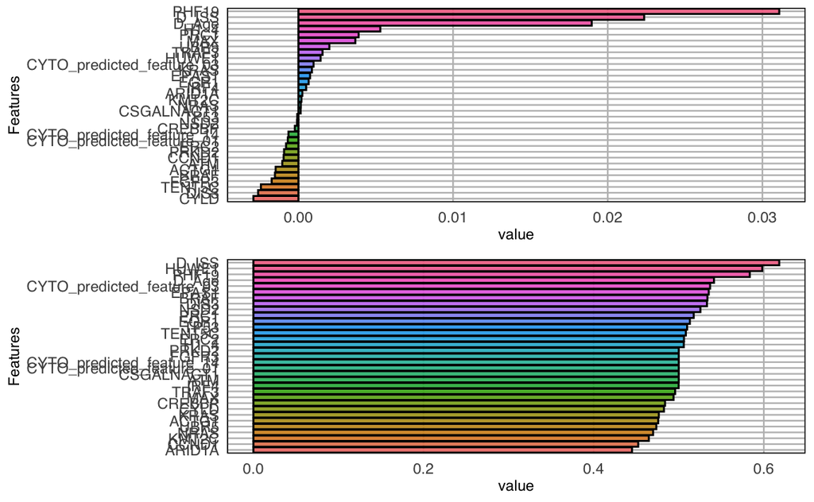

```r
## remove irrelevant columns from the dataset
train_data <- clin_exp_merge %>% dplyr::select(-c("RNASeq_transLevelExpFileSamplId", "Patient", "agegrp", "D_Gender"))

## generate random forest SRC importance plots
rfi=generateFilterValuesData(surv.task,method=c("randomForestSRC_importance"))%>%.$data%>%ggplot(aes(x=reorder(name,value),y=value,fill=reorder(name,value)))+geom_bar(alpha=0.8,stat="identity",color="black",show.legend=F)+scale_x_discrete("Features")+coord_flip()

## generate Cox-PH model nivariate scores
uv=generateFilterValuesData(surv.task,imp.learner=makeLearner("surv.coxph"),method="univariate.model.score")%>%.$data%>%ggplot(aes(x=reorder(name,value),y=value,fill=reorder(name,value)))+geom_bar(alpha=0.8,stat="identity",color="black",show.legend=F)+scale_x_discrete("Features")+coord_flip()

## plot
grid.arrange(rfi,uv)
```

Results show some features are not important predictors, however, they still might contribute to the mortality risk (based on the univariate model). Thus, all features from the dataset will be included in our model.

#### 2. Benchmark study: CoxPH vs Random forest SRC

Based on Cross-validation for comparing the performance of the 2 survival analysis algorithms

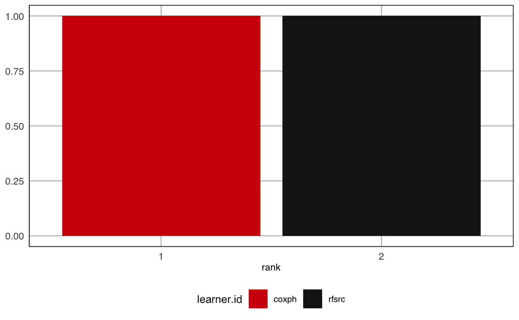

```r
par(mfrow=c(1,3))
## make survival task
surv.task <- makeSurvTask(data=train_data, target = c("D_PFS", "HR_FLAG"))


## z-score normalize all numeric features
surv.task <- normalizeFeatures(surv.task, method="standardize", cols=c("D_Age", "ACTG1", "ARID1A", "ATM",
                                                                       "BRAF", "CCND1", "CREBBP", "CSGALNACT1", "CYLD", "DIS3", "EGR1",
                                                                       "EPAS1", "ERC2", "FGFR3", "H1_4", "HUWE1", "IRF4", "KMT2C", "KRAS",
                                                                       "MAX", "NRAS", "NSD2", "PHF19", "PRC1", "PRKD2", "TENT5C", "TP53",
                                                                       "TRAF3", "UBR5"))

#Benchmark study : comparing 2 different algorithms for survival task

# Creating a list of 2 learners
svlearners=list(
  makeLearner("surv.coxph"),
  makeLearner("surv.randomForestSRC")
)

## 5-fold cross-validation
rdesc=makeResampleDesc("CV", iters=5, predict = "both")

# Initalising the Benchmark study
set.seed(123)
svbnmrk=benchmark(svlearners,surv.task,rdesc)

bmrkdata=getBMRPerformances(svbnmrk, as.df = TRUE)%>%.[,-1]

## plot and check the performance of the two learners
## Distribution of C-index of 2 survival algorithms, based on a 5-fold cross-validation
plotBMRRanksAsBarChart(svbnmrk)+scale_fill_manual(values=myfillcolors)
```

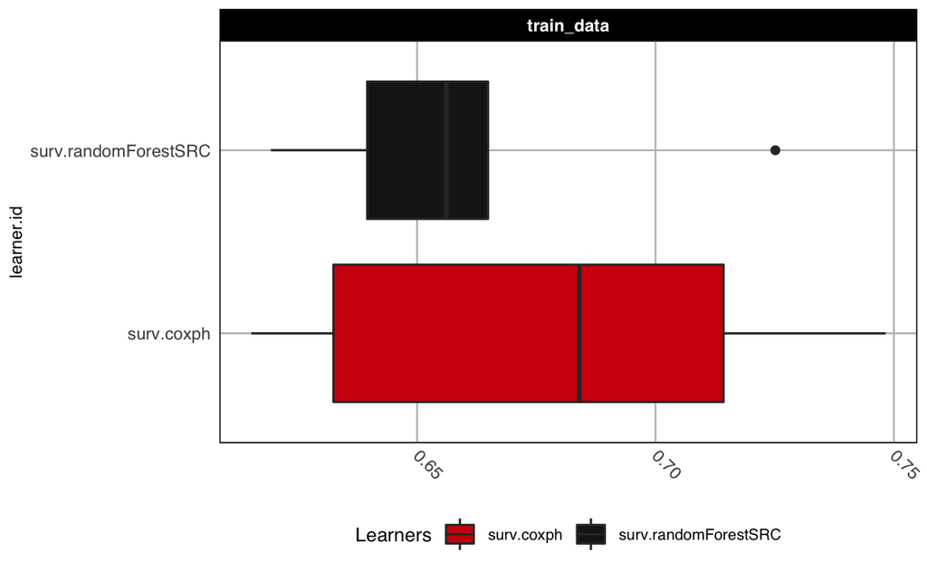

```r
plotBMRBoxplots(svbnmrk)+aes(fill=learner.id)+coord_flip()+scale_fill_manual(values=myfillcolors,name="Learners")
```

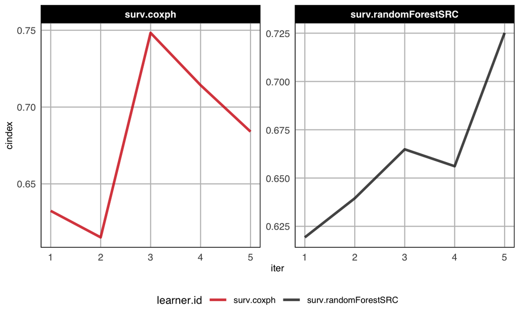

```r
ggplot(bmrkdata)+geom_path(aes(x=iter,y=cindex,color=learner.id),size=1,alpha=0.8)+facet_wrap(~learner.id,scales="free",ncol=2)+scale_color_manual(values=myfillcolors)
```

#### 3. Build Random Forest SRC model

```r
## make final learner (random forest SRC)
svlearner <- makeLearner("surv.randomForestSRC")

## set parameter space
params <- makeParamSet(makeDiscreteParam("mtry", c(2,4,6,8,10)), makeDiscreteParam("ntree", c(3,10,50,100,300,1000)))

## define type of search (GridsearchCV)
ctrl <- makeTuneControlGrid()

## define CV scheme (5-fold CV)
rdesc=makeResampleDesc("CV", iters=5, predict = "both")

set.seed(2356)

## tune hyperparameters
tune <- tuneParams(learner=svlearner, task=surv.task, resampling=rdesc, par.set=params, control = ctrl,
                   show.info=T)

## change params (take only optimal params)
svlearner_tune <- setHyperPars(makeLearner("surv.randomForestSRC"), mtry=tune$x$mtry, ntree=tune$x$ntree)

svlearner_tune$par.vals <- list(importance=T)

## resampling - to anticipate how the model might possibly perform on a new dataset
## the CV scheme in mlr by default makes 80/20 split of the training dataset
cv <- resample(svlearner_tune, surv.task, rdesc, measures=cindex, models=T, extract=getFeatureImportance)

#train a model
rforestsrc <- train(svlearner_tune, surv.task)
```

#### 4. Feature importance

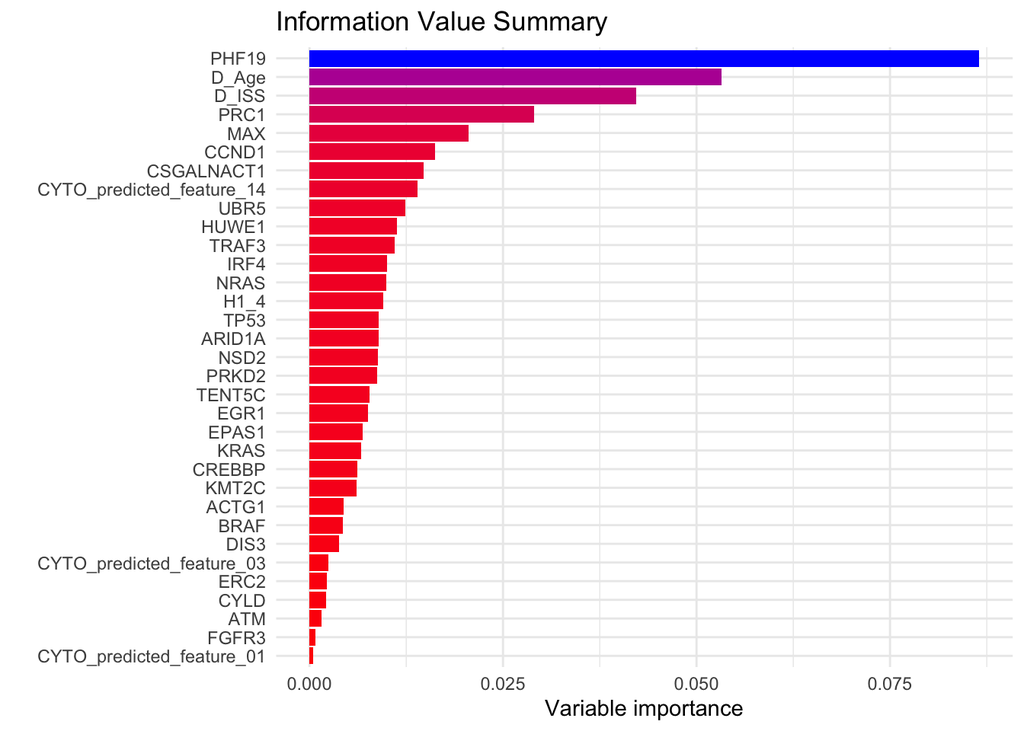

```r
## get feature importance using the cross validation set (average of all models)
imp_df_cv <- rbind(cv$extract[[1]]$res,
                   cv$extract[[2]]$res,
                   cv$extract[[3]]$res,
                   cv$extract[[4]]$res,
                   cv$extract[[5]]$res)%>% dplyr::group_by(variable) %>% dplyr::summarise(mean=mean(importance), sd=sd(importance)) %>% arrange(desc(mean))

ggplot(imp_df_cv, aes(x=reorder(variable, mean), y=mean, fill=mean))+
  geom_bar(stat="identity", position="dodge")+coord_flip()+
  ylab("Variable importance")+xlab("")+ggtitle("Information Value Summary")+
  guides(fill=F)+scale_fill_gradient(low="red", high="blue")+theme_minimal()
```

#### 5. Kaplan-Meier curves for the top 5 important genes

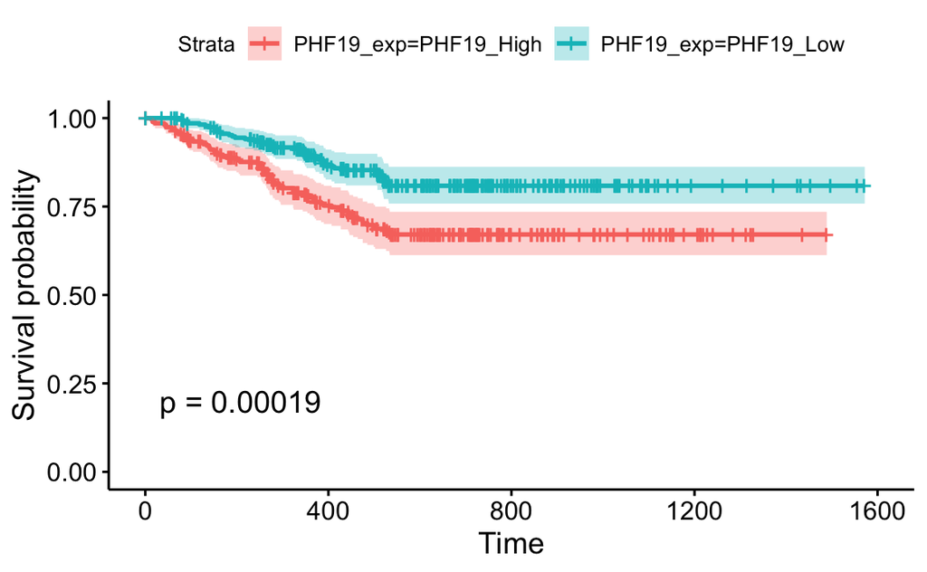

```r
par(mfrow=c(2,3))
## first:divide patients into two groups using gene expression median as a cutoff
clin_exp_merge = clin_exp_merge %>%
  mutate(PHF19_exp = case_when(
    PHF19 > quantile(PHF19, 0.5) ~ 'PHF19_High',
    PHF19 < quantile(PHF19, 0.5) ~ 'PHF19_Low',
    TRUE ~ NA_character_
  ))

clin_exp_merge = clin_exp_merge %>%
  mutate(PRC1_exp = case_when(
    PRC1 > quantile(PRC1, 0.5) ~ 'PRC1_High',
    PRC1< quantile(PRC1, 0.5) ~ 'PRC1_Low',
    TRUE ~ NA_character_
  ))

clin_exp_merge = clin_exp_merge %>%
  mutate(MAX_exp = case_when(
    MAX > quantile(MAX, 0.5) ~ 'MAX_High',
    MAX< quantile(MAX, 0.5) ~ 'MAX_Low',
    TRUE ~ NA_character_
  ))

clin_exp_merge = clin_exp_merge %>%
  mutate(CCND1_exp = case_when(
    CCND1 > quantile(CCND1, 0.5) ~ 'CCND1_High',
    CCND1< quantile(CCND1, 0.5) ~ 'CCND1_Low',
    TRUE ~ NA_character_
  ))

clin_exp_merge = clin_exp_merge %>%
  mutate(CSGALNACT1_exp = case_when(
    CSGALNACT1> quantile(CSGALNACT1, 0.5) ~ 'CSGALNACT1_High',
    CSGALNACT1< quantile(CSGALNACT1, 0.5) ~ 'CSGALNACT1_Low',
    TRUE ~ NA_character_
  ))

fit_phf19 = survival::survfit(Surv(D_PFS, HR_FLAG) ~ PHF19_exp, data = clin_exp_merge)
fit_prc1 = survival::survfit(Surv(D_PFS, HR_FLAG) ~ PRC1_exp, data = clin_exp_merge)
fit_max = survival::survfit(Surv(D_PFS, HR_FLAG) ~ MAX_exp, data = clin_exp_merge)
fit_ccnd1 = survival::survfit(Surv(D_PFS, HR_FLAG) ~ CCND1_exp, data = clin_exp_merge)
fit_csg = survival::survfit(Surv(D_PFS, HR_FLAG) ~ CSGALNACT1_exp, data = clin_exp_merge)

ggsurvplot(fit_phf19, pval = T, conf.int = T)
```

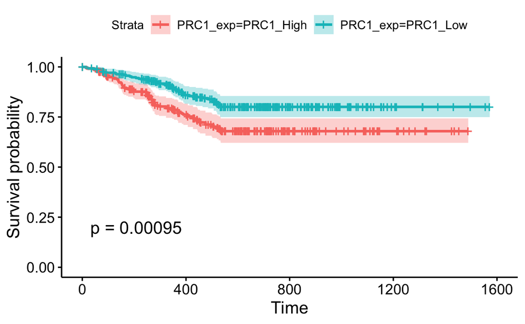

```r
ggsurvplot(fit_prc1, pval = T, conf.int = T)
```

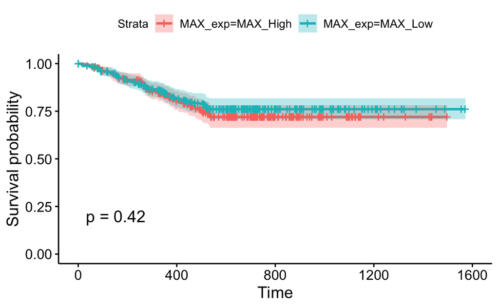

```r
ggsurvplot(fit_max, pval = T, conf.int = T)
```

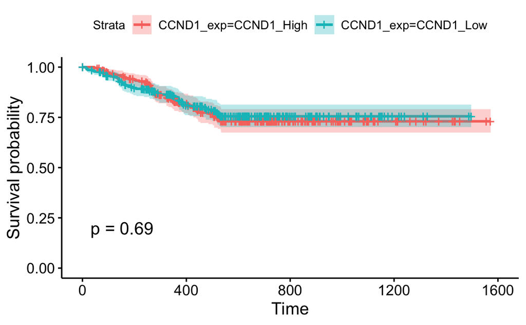

```r
ggsurvplot(fit_ccnd1, pval = T, conf.int = T)
```

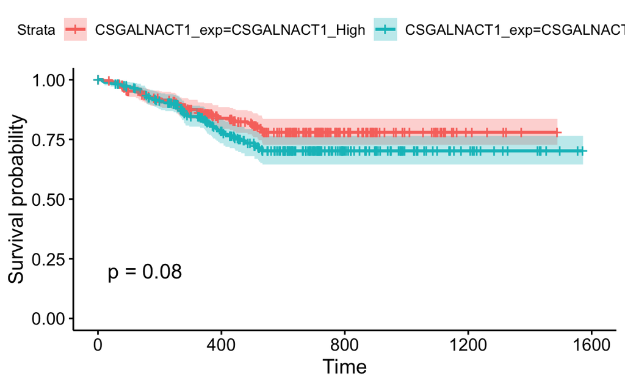

```r
ggsurvplot(fit_csg, pval = T, conf.int = T)
```